# One-Way ANOVA

Parametric Shortcut Guide

Author

Neil J. Hatfield

Modified

October 27, 2026

In this guide, we are going to explore using R to fit a One-way ANOVA model using the parametric shortcut known as the One-way ANOVA *F* Test. I’ll interweaving a couple of different examples throughout the text.

# 1 Getting Ready

When getting ready to do anything in R, you’ll always want to take a moment and ensure that you identify what packages and data you’ll need. Then you should load those items. Again, a good habit to get into is to always start your R script (or your first code chunk) by loading packages, setting any global options, and loading data.

**Note**

If you are using other statistical software, you might not need to load additional tools. This is highly dependent upon your choice of software.

## 1.1 Loading Packages in R

In this guide, we will make use of several packages. Specifically, we will use `{tidyverse}`, `{hasseDiagram}`, `{knitr}`, `{kableExtra}`, `{car}`, `{psych}`, `{parameters}`, and `{emmeans}`. You can load these packages into your session by using the `library` function either in the Console, as part of a R script, or in a code chunk towards the top of your R Markdown/Quarto file. Below is the example code that I’m running.

```r
# Load useful packages ----
packages <- c("tidyverse", "hasseDiagram", "knitr", "kableExtra",
              "car", "psych", "parameters", "emmeans")
lapply(
  X = packages,
  FUN = library,
  character.only = TRUE,
  quietly = TRUE
)
```

The `lapply` function lets me apply the `library` call to all of the package names that I placed in the `packages` object. This allows me to not need to write eight separate `library` calls.

If you do not have these packages installed (e.g., you attempt to run the above code and get an error message that R can’t find something), please refer to the [Getting Started](https://neilhatfield.github.io/STAT461/codingRGuides/Starting%20Guides/Stat461.GettingStarted.html) guide for guidance on getting R set up.

## 1.2 Set Global Options

There are a couple of options that we should set at this time. These will help ensure that R works the way the we intend for *this* class. I generally set options right after I load packages.

### 1.2.1 Set Our Constraint

Recall that we are using a particular side condition or constraint that directly relates to our factor effects: we are requiring the effects of each factor to add to zero. Mathematically that constraint looks like
$$\sum_i^g\alpha_i\cdot n_i=0$$

To get R to use this constraint rather than its default, we need to run the following command:

```r
# Code for setting the constraint ----
options(contrasts = c("contr.sum", "contr.poly"))
```

**Warning**

If you are using another statistical software, you’ll need to investigate what constraint it uses and how you change that setting (if possible). Reach out to me and I can help you.

### 1.2.2 Empty Table Cells

To make professional looking tables in a R Markdown file, I recommend using the `{knitr}` and `{kableExtra}` packages. One thing to keep in mind is that by default, `R` does not like truly empty table cells and typically prints “NA” in them. Thus, to keep our tables as uncluttered as possible, we need to instruct `R` to leave empty table cells visually empty. We can do this with the following code:

```r
# Code for controlling table options ----
# Tell Knitr to use empty space instead of NA in printed tables
options(knitr.kable.NA = "")
```

## 1.3 Load Data

Once you have set the `R` options, now comes reading in data. For this guide, we’re going to work with three different data sets: the Fall 2023 Song Knowledge data, data from a honey study, and data from Example 3.2 Resin Lifetimes from the Oehlert textbook.

The following code demonstrates how we can read in the three data sets:

```r
# Code for Loading Data ----
## Song Data
songData <- read.table(
  file = "https://raw.githubusercontent.com/neilhatfield/STAT461/main/dataFiles/songKnowledge_Fa23.csv",
  header = TRUE,
  sep = ","
)
### Set year to an ordered factor
songData$Year <- factor(
  x = songData$Year,
  levels = c("Junior", "Senior", "Other")
)

## Honey Data--Manual Entry
honey <- data.frame(
  Amount = c(150, 50, 100, 85, 90, 95, 130, 50, 80),
  Varietal = rep(c("Clover", "Orange Blossom", "Alfalfa"), each = 3)
)
### Set Varietal to factor (no particular order)
honey$Varietal <- as.factor(honey$Varietal)

## Resin Lifetimes Data
resin <- read.table(
  file = "https://raw.github.com/neilhatfield/STAT461/main/dataFiles/resinLifetimes.dat",
  header = TRUE,
  sep = "" # Notice the change in separator
)
#### Set temp to factor
resin$temp <- as.factor(resin$temp)

### Change the name of the y column to something more meaningful
names(resin)[which(names(resin) == "y")] <- "log10Lifetime"
```

If you want to follow along with the guide, now would be a good time to copy and run the above code in your own session of R.

## 1.4 Additional Tools

Over the years I have created some additional tools which can be useful as you perform ANOVA analyses. To access them, you must first load them into your R session by running the following command either in your script or as part of your R Markdown/Quarto document:

```r
# Code for loading Neil's extra tools ----
source("https://raw.github.com/neilhatfield/STAT461/main/rScripts/ANOVATools.R")
```

This is typically the last line of code in my first code chunk of any R Markdown/Quarto file.

# 2 Explore Your Data

At this point in time, you should engage in exploratory data analysis including creating professional looking data visualizations (I recommend using the `{ggplot2}` package) as well as looking at descriptive statistics by groups (I recommend using `{psych}` or `{dplyr}` packages). For more details on both of these topics, see the starting guides for [Data Visualizations](https://neilhatfield.github.io/STAT461/codingRGuides/Starting%20Guides/Stat461.DataVisualizations.html) and [Descriptive Statistics](https://neilhatfield.github.io/STAT461/codingRGuides/Starting%20Guides/Stat461.DescriptiveStatistics.html).

## 2.1 Your Turn

Explore the data from any of the three studies used in this guide, the data from the class’s first study, and/or any other data you have access to. What do you find? What do you notice?

# 3 Is ANOVA Even Appropriate?

Recall the base requirements for One-way ANOVA are:

- From Unit 2
  - you are working with a qualitative/categorical factor,
  - you are working with a quantitative response,
- From Unit 3
  - you are working with an additive model,
  - you have estimable effects, and
  - you have estimable errors/residuals.

## 3.1 Checking the Unit 2 Requirements

The first two requirements (from Unit 2) you can check quickly in R by using the `str` (“structure”) function or by clicking on the blue circle with a white triangle to the left of each data frame’s name in the Environment tab of R Studio. This is *not* something that you put into any reports. Rather, this is something you should check for yourself. In essence, this is to make sure R is thinking about your data in the same way that you are.

```r
# Checking the first two base requirements
str(songData)
```

```
'data.frame':   12 obs. of  2 variables:
 $ Year : Factor w/ 3 levels "Junior","Senior",..: 1 1 1 1 3 3 3 3 2 2 ...
 $ Score: int  7 12 3 6 1 2 6 9 0 3 ...
```

```r
str(honey)
```

```
'data.frame':   9 obs. of  2 variables:
 $ Amount  : num  150 50 100 85 90 95 130 50 80
 $ Varietal: Factor w/ 3 levels "Alfalfa","Clover",..: 2 2 2 3 3 3 1 1 1
```

```r
str(resin)
```

```
'data.frame':   37 obs. of  2 variables:
 $ temp         : Factor w/ 5 levels "175","194","213",..: 1 1 1 1 1 1 1 1 2 2 ...
 $ log10Lifetime: num  2.04 1.91 2 1.92 1.85 1.96 1.88 1.9 1.66 1.71 ...
```

What we want to see is that for each factor, R has the word “`Factor`” immediately after their (column) name. For our response, we want to see either “`num`” or “`int`” after their (column) name. If we see these AND they match our expectations of the data, then we can say that we’ve met these two requirements.

## 3.2 Checking the Unit 3 Requirement: Hasse Diagrams

The last three base requirements (from Unit 3) stem from the Hasse diagram. Essentially, if you can build the Hasse diagram and have positive (i.e., non-zero and non-negative) degrees of freedom everywhere, then all three of these are satisfied.

Hasse diagrams can be included in your reports. The following is an example for how we might do so with the Honey study. For putting Hasse diagrams into your R Markdown/Quarto files, I recommend using the [Hasse Diagram App](https://psu-eberly.shinyapps.io/Hasse_Diagrams/) and copying the R code generated there.

### 3.2.1 Example-Honey Study

In investigating the effect of the type of varietal (species of flower) has on the production of excess honey, we constructed the Hasse diagram in Figure 1. With our nine hives of the same species of bee, we can see that we have sufficient degrees of freedom to estimate the effects for our three levels of varietal and have degrees of freedom for our error term. Given that we’re measuring our response (excess honey) in pounds, along with the additive model shown in Figure 1, a one-way ANOVA model is a valid approach.

Figure 1: Hasse Diagram for Honey Study

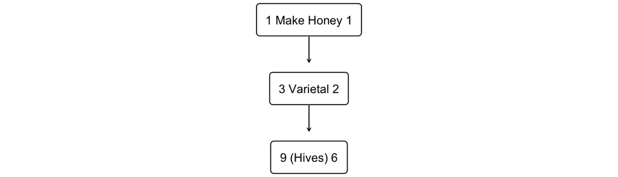

```r
# Code for a Hasse Diagram ----
## The Honey Study
modelLabels <- c("1 Make Honey 1", "3 Varietal 2", "9 (Hives) 6")
modelMatrix <- matrix(
  data = c(FALSE, FALSE, FALSE, TRUE, FALSE, FALSE, TRUE, TRUE, FALSE),
  nrow = 3,
  ncol = 3,
  byrow = FALSE
)
hasseDiagram::hasse(
 data = modelMatrix,
 labels = modelLabels
)
```

**Long Description**

The Hasse diagram has three nodes in three levels. Nodes are sequentially connected by downwards pointing arrows.

The first node at the top level says "1 Make Honey 1".

The second node at the middle level says "3 Varietal 2".

The third node is at the bottom level says "9 (Hives) 6".

### 3.2.2 Your Turn

Try creating the code (either on your own or via the app) for the Hasse diagrams for the Song Knowledge and the Resin Lifetime studies (see p. 32 of Oehlert).

# 4 Fit the ANOVA Model

In order to check out the assumptions of the Parametric Shortcut (a.k.a. “the ANOVA *F* Test”), we first need to fit the ANOVA model in R. This will enable us to access the residuals in an easy way. I must give a word of caution here: don’t look at the results of the model just yet. You must first assess all of the assumptions so that you can build your trust in the results.

To fit our ANOVA model, we will primarily use the `aov` function that is part of base R. (You can also use the `lm` function with the same arguments.) We will want to save our model to a named object so that we can call them at later times. Here is how we would build/fit the model:

```r
# Code for Building ANOVA Models ----
## Song Knowledge study
songModel <- aov(
  formula = Score ~ Year,
  data = songData,
  na.action = "na.omit"
)
```

**1**

We will want to save the output of the `aov` function hence why I’ve started this line with the name `songModel` followed by the assignment operator, `<-`.

**2**

The `formula` argument is how we express our model. In essence, you put in all of our factors/terms. R automatically knows to account for the first and last nodes of our Hasse diagrams (the action screen and measurement units). The structure of the formulas are `responseName ~ factorName`.

**3**

The `data` argument is where you tell `aov` the name of the data frame you want to use.

**4**

The `na.action` argument is a safety precaution. You are instructing `R` that if there is an observation with missing values, then `R` is to omit that observation from the model. (You may leave this argument off if you desire and are willing to run the risk of problems.)

The pattern of the `aov` call I used in for the Song Knowledge study is going to be the pattern that we’ll want to emulate for other sets.

## 4.1 Your Turn

Try to emulate the `aov` call for the Honey and Resin Lifetime Studies. When you’re ready, you can check your answers below.

**NoteHoney Study Example**

```r
# Code for Building ANOVA Models ----
## Honey study
honeyModel <- aov(
  formula = Amount ~ Varietal,
  data = honey,
  na.action = "na.omit"
)
```

**NoteResin Lifetimes Study Example**

```r
# Code for Building ANOVA Models ----
## Resin Lifetime study
resinModel <- aov(
  formula = log10Lifetime ~ temp,
  data = resin,
  na.action = "na.omit"
)
```

# 5 Assessing Assumptions

Before we look at the results of fitting the ANOVA model, we must first assess the assumptions. R automatically does the parametric shortcut test when we call the results of fitting the model–regardless of whether the parametric shortcut is actually valid. Thus, we need to be convinced that we’ve met the assumptions of the test well enough to trust the results.

For the parametric shortcut (a.k.a. “the ANOVA *F* test”), there are three assumptions:

1. Our residuals need to follow a Gaussian distribution.
2. We have homoscedasticity (around the model) among the residuals.
3. We have Independent Observations.

We will need to access the residuals from our model. We can do this in two different ways: we can use the extractor operator, `$`, or we can use the `residuals` function. For example, `songModel$residuals` or `residuals(songModel)`. Either method will give us the same set of values to work with.

Remember, we want to **assess not test** our assumptions. Thus, we will be relying on specific data visualizations and a couple of descriptive statistics to help us. All of which can go into your reports.

## 5.1 Gaussian Residuals

The first assumption for the parametric shortcut is that our residuals follow a Gaussian distribution (a.k.a. a “normal” distribution). The primary tool that we’ll use here is a Quantile-Quantile (QQ) plot. We can supplement this tool with two statistics.

### 5.1.1 QQ Plots

There are multiple functions that will produce QQ plots in R; one of the better versions comes from the `{car}` package.

```r
# Code for Making a QQ Plot of Residuals ----
## Song Knowledge Study
car::qqPlot(
  x = songModel$residuals,
  distribution = "norm",
  envelope = 0.9,
  id = FALSE,
  pch = 20,
  ylab = "Residuals (points)"
)
```

**1**

Pass our residuals to the `x` argument from our model.

**2**

While our assumption focuses on the Gaussian (“normal”) distribution, we can use the `distribution` argument to test against other named distributions.

**3**

The `envelope` argument controls whether to add a confidence envelope with the given level (here, 90%).

**4**

The `id` argument controls whether to label the two points that have the most extreme vertical values.

**5**

The point character argument, `pch`, controls the size and shape of the points in the plot. Filled dots are 19 (larger) and 20 (smaller).

**6**

Make sure to adjust the axis label to match the current context.

Figure 2: Residuals QQ Plot for Song Knowledge Study

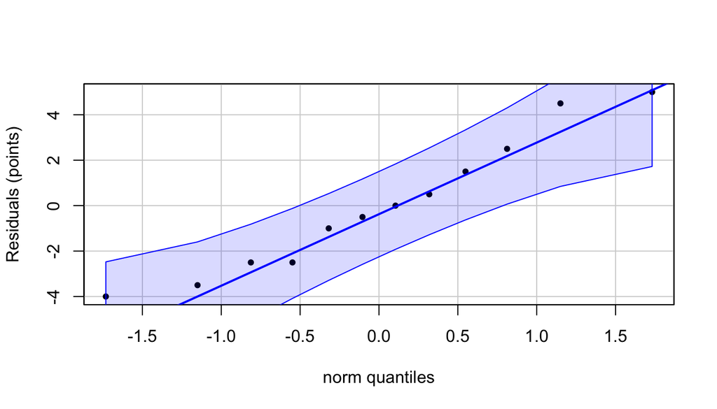

**Long Description**

The horizontal axis is labelled “norm quantiles” and goes from about –2 to about +2 with labels of -1.5, -1, -0.5, 0, 0.5, 1, and 1.5. The vertical axis is labelled “Resdiduals (points)” and goes from about –4 to about 5 with labels -4, -2, 0, 2, and 4. The plot contains three sets of elements.

- A straight, solid blue line indicating the perfect matching of quantiles going from the point (-1.25, -4) to the point (1.75, 5).
- Two curved blue lines on either side of the perfect match line. These curves flair away from the perfect match line towards the ends of the plot and narrow in towards the line in the plot’s middle. The curved lines establish the 90% confidence envelope.
- There are set of 12 points, each one representing a case from the data set. Their position is set by where that case’s residual would be ordered according to the theoretical Gaussian distribution as the horizontal axis and the data-driven ordering as the vertical axis.
- The points are arranged in an upward pattern following the perfect match line but are not in a perfectly straight line. There are some points that move away from the perfect match line towards the middle of the plot.
- Of the 12 points, none are outside of the confidence envelope and none are touching the edges of the confidence envelope.

When we use a QQ plot, keep in mind that the solid blue line reflects the perfect matching between the theoretical distribution and real-world data. Our points generally won’t be absolutely on the line. The confidence envelope provides us with a way to see how many points might be *too far* away from the perfect match line. We need to know what confidence level was used to make the envelope. In Figure 2, we have a 90% confidence envelope; thus we can have up to 10% of the points outside of the envelope before we get concerned about the assumption. Based off of Figure 2, there are no residuals outside of the envelope and the points appear to follow the trend of the perfect match line without much deviation. I would say that Gaussian assumption is satisfied for this model.

#### 5.1.1.1 Your Turn

Try replicating the QQ plot for the Honey Study. When you are ready, take a look at the answer below.

**NoteHoney Study Example**

Figure 3: Residuals QQ Plot for Honey Study

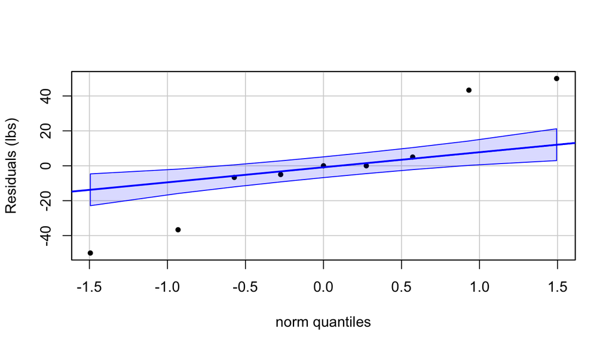

```r
# Code for making QQ Plot of Residuals ----
## Honey Study
car::qqPlot(
  x = honeyModel$residuals,
  distribution = "norm",
  envelope = 0.9,
  id = FALSE,
  pch = 20,
  ylab = "Residuals (lbs)"
)
```

**Long Description**

The horizontal axis is labelled “norm quantiles” and goes from about –1.6 to about +1.6 with labels of -1.5, -1, -0.5, 0, 0.5, 1, and 1.5. The vertical axis is labelled “Resdiduals (lbs)” and goes from about –50 to about 50 with labels -40, -20, 0, 20, and 40. The plot contains three sets of elements.

- A straight, solid blue line indicating the perfect matching of quantiles going from the point (-1.6, -15) to the point (1.6, 15).
- Two curved blue lines on either side of the perfect match line. These curves flair away from the perfect match line towards the ends of the plot and narrow in towards the line in the plot’s middle. The curved lines establish the 90% confidence envelope.
- There are set of 9 points, each one representing a case from the data set. Their position is set by where that case’s residual would be ordered according to the theoretical Gaussian distribution as the horizontal axis and the data-driven ordering as the vertical axis.
- The points are arranged in an upward pattern going from the lower left to the upper right.
- Of the 9 points, four are outside of the confidence envelope.
- The first two points are well below the envelope.
- After shape bend upwards, the next five points are within the envelop and follow the perfect match line.
- The last two points occur after another sharp bend upwards in the pattern and lie well above the envelope.

### 5.1.2 Two Statistics

Another tool that you can use for assessing the Gaussian assumption are two descriptive statistics: *Sample Skewness* and *Sample Excess Kurtosis*. These are generated by the `{psych}` package’s `describe` function (i.e., the `psych::describe(songModel$residuals)`. You can also call them directly with `psych::skew(songModel$residuals)` and `psych::kurtosi(songModel$residuals)`. Ideally, we want the value of *Sample Skewness* and *Sample Excess Kurtosis* to be as close to zero as possible.

**Tip**

Something to keep in mind about the values of *Sample Skewness* and *Sample Excess Kurtosis* is that their magnitudes are challenging to interpret. The context of the study matters. Thus, there is **NO** magic cutoff/rule of thumb for deciding how large (in magnitude) is *too* large for either of these statistics.

Some magnitudes are easier to make a decision than others. For example, consider the following values of *Sample Excess Kurtosis*: $1.2\times10^{-1}$, $-2.1\times10^0$, and $2.1\times10^2$. Statisticians tend to be in general agreement that the first and third are easy to classify (not that far from 0 and way off from 0, respectively). However, the -2.1 is harder to decide. Thus, these statistics are almost never used alone but in conjunction with a QQ plot or some other data visualization (e.g., a worm plot or de-trended QQ plot).

For the Song Knowledge context, the value of *Sample Skewness* is 0.31 and the value of *Sample Excess Kurtosis* is -1.29. When we partner these values with the QQ plot, we can say that we’re satisfied with the Gaussian assumption being met.

#### 5.1.2.1 Your Turn

Use either the `describe` function or the pair of `skew` and `kurtosi` functions to get the values of the statistics for the Honey Study. When ready, check the answer below.

**NoteHoney Study Example**

```r
# Code for Getting Sample Skewness and Sample Excess Kurtosis ----
## Honey Study
psych::skew(honeyModel$residuals)
```

```
[1] 0.1053397
```

```r
psych::kurtosi(honeyModel$residuals)
```

```
[1] -1.166183
```

### 5.1.3 Putting Things Together

You’ve now seen how to assess the Gaussian assumption using QQ plots and a pair of statistics. The Song Knowledge study satisfied the assumption while the Honey study did not. Practice applying both methods to the Resin Lifetimes study data. How do you feel about whether the Gaussian Residuals assumption is satisfied?

## 5.2 Homoscedasticity

The second assumption for the parametric shortcut is that of homoscedasticity. This assumption deals with there being the same or similar amounts of variation within each group (around our model). For this assumption, you can make use of the values of the *Sample Arithmetic Standard Deviation* or *Sample Arithmetic Variance* IF you are looking by groups. The `describeBy` function from the `psych` package is your friend here. However, there is also visual method which you can use: the strip chart.

A strip chart is a variation on a scatter plot. If you have done regression, you might have looked at a scatter plot of residuals by fitted values. A strip chart is the same idea. However, rather than having many different fitted values, we’ll only have the same number of fitted values as groups. This is what creates the strips. For this visualization, we will use the `{ggplot2}` package rather than the output of the `plot` function. (We always want to aim for professional looking plots.)

```r
# Code for Making Strip Charts ----
## Song Knowledge study
ggplot(
  data = data.frame(
    residuals = songModel$residuals,
    fitted = songModel$fitted.values
  ),
  mapping = aes(x = fitted, y = residuals)
) +
  geom_point(size = 2) +
  theme_bw() +
  labs(
    x = "Fitted values (points)",
    y = "Residuals (points)"
  )
```

**1**

We will need to construct a temporary data frame to house the residuals and fitted values from our model. You just need to adjust the model object name to match the current model you’re working with (i.e., replace `songModel`).

**2**

The `size` argument controls the size of the points. You can omit/change this value to improve the appearance of your plot.

**3**

Don’t forget to update the labels on the axes to match your current context.

Figure 4: Strip Chart for Song Knowledge Study

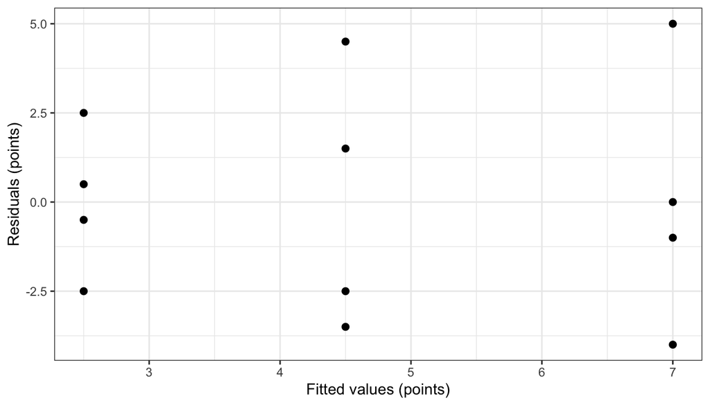

**Long Description**

The horizontal axis is labelled “Fitted values (points)” and goes from a little below 2.5 to a little above 7 with labels of 3, 4, 5, 6, and 7. The vertical axis is labelled “Residuals (points)” and goes from about a bit below -3.75 to a bit above 5 with labels of -2.5, 0, 2.5, and 5.

There are 12 points arranged into three strips of four points.

The first strip is located at a fitted value of 2.5 with the points spaced vertically from -2.5 to +2.5

The second strip is located at a fitted value of 4.5 with the points spaced vertically from about -3.7 to 4.5.

The third strip is located at a fitted value of 7 with the points spaced vertically from -3.8 to 5.

The code for creating strip charts is meant to be highly reusable. At minimum, you just need to swap out the name of the model object and update the labels for the axes.

When we look at strip charts for assessing homoscedasticity, we’re primarily focused two aspects: comparing the lengths of the strips and if there are any patterns.

In Figure 4, we have three strips of four points. The lengths of these strips are such that the first strip just about half that of the third strip. This is a rule of thumb that we want to look out for: if any group has more than twice the length of another group, we should start worrying about homoscedasticity. Keep in mind that having a single group with different amount of variation is not a terminal violation, especially if we have a balanced design. However, we will want to proceed with caution.

A bigger issue for homoscedasticity is that of patterns in a strip chart. The most common patterns to look out for are megaphones or funnels. We have a (right-opening) megaphone if the length of the strips get larger as you move from the left to the right along the horizontal axis. We have a funnel (left-opening megaphone) if the length of the strips gets smaller as you move from left to right. Keep an eye out for other patterns or shapes. These indicate deeper issues that result in violating the homoscedasticity assumption.

### 5.2.1 Your Turn

Build a strip chart for the Honey Study. When you’re ready check your answer below.

**NoteHoney Study Example**

Figure 5: Strip Chart for Honey Study

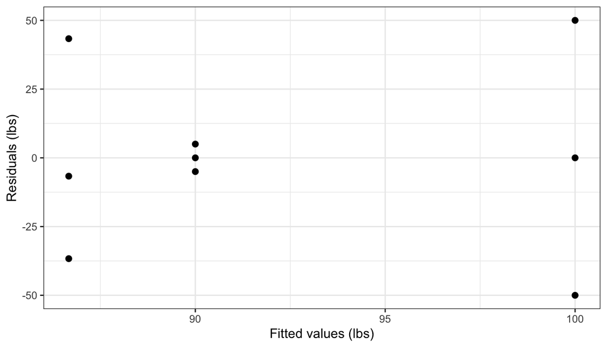

```r
# Code for Making Strip Charts ----
## Honey study
ggplot(
  data = data.frame(
    residuals = honeyModel$residuals,
    fitted = honeyModel$fitted.values
  ),
  mapping = aes(x = fitted, y = residuals)
) +
  geom_point(size = 2) +
  theme_bw() +
  labs(
    x = "Fitted values (lbs)",
    y = "Residuals (lbs)"
  )
```

**Long Description**

The horizontal axis is labelled “Fitted values (lbs)” and goes from a about 87 to about 103 with labels of 90, 95, and 100. The vertical axis is labelled “Residuals (lbs)” and goes from about a bit below -50 to a bit above 50 with labels of -50, -25, 0, 25, and 50.

There are 9 points arranged into three strips of three points.

The first strip is located at a fitted value of about 87 with the points spaced vertically from -37 to +40

The second strip is located at a fitted value of 90 with the points spaced vertically from about -6 to 6.

The third strip is located at a fitted value of 100 with the points spaced vertically from -50 to 50.

For the Honey study, we’ve violated the homoscedasticity assumption (see Figure 5).

For the Song Knowledge study, I might look into the nonparametric shortcut known as Kruskal-Wallis $H$ test or use a simulation in conjunction with the parametric shortcut. In the Honey Study, I would recommend either applying some type of variance-stabilizing transformation (see Table 6.3 in the Oehlert text) or using the nonparametric shortcut.

### 5.2.2 Putting Things Together

You’ve now seen how to assess the Homoscedasticity assumption using a strip chart. Practice applying this method to the Resin Lifetimes study data. How do you feel about whether the Homoscedasticity assumption is satisfied?

## 5.3 Independence of Observations

The last assumption is not only the most important but the hardest assumption to check. I want to stress that this assumption is about the *Independence of Observations*. There are many kinds of independence in Statistics (e.g., independence of attributes), thus you need to clearly articulate which kind of independence you’re talking about.

### 5.3.1 Knowledge of Study Design and Sample

The first method we have available to us is not graphical or statistical in nature. Rather, we focus on what we know about the study design, how the data were collected, and the make up of the sample (i.e., the measurement units). For example, did we take precautions to draw a random sample for our measurement units? Did we take a convenience sample? Did we end up getting a chunk of closely related family members? Think through all possible ways that we could end up with measurement units directly impacting each other and then check the study to see if any of those methods could have/did slip through our guards.

For the Song Knowledge study, while all students who were present that day took part, not everyone agreed to participate for our data. Further, we took a random sample stratified by year in school resulting in the 12 students in our sample. Given how we designed our study, we might cautiously argue that we have satisfied the assumption of Independent Observations.

### 5.3.2 Knowledge of Measurement Order

If we explicitly know the order in which we took measurements from our measurement units, then we can make use of two analytical tools: index plots and the Durbin-Watson statistic. While we do not know the measurement order for the Song Knowledge study, I do know the order the hives were measured for the Honey study and ordered the data values in that order.

**WarningOrder of Data**

Unless you are explicitly told that data appear in the file in measurement order, you should not assume that data come to you in measurement order.

You’ll want to wrangle the data so that they appear in measurement order in your data frame. The `arrange` function from `{dplyr}` is particularly useful for this task, provided you have a column for measurement order in the data frame (or have added one). Once you have the data in order, then you should then fit the model with the `aov` call.

#### 5.3.2.1 Index Plot

Since I knew measurement order when I created the data frame and placed the data values in that order, we can make use of an Index plot.

```r
# Code for Index Plots ----
## Honey Study
ggplot(
  data = data.frame(
    residuals = honeyModel$residuals,
    index = 1:length(honeyModel$residuals)
  ),
  mapping = aes(x = index, y = residuals)
) +
  geom_point(size = 1.5) +
  geom_line() +
  theme_bw() +
  geom_hline(
    yintercept = 0,
    linetype = "dashed",
    color = "red"
  ) +
  labs(
    x = "Measurement order",
    y = "Residuals (lbs)"
  )
```

**1**

We again need to construct a temporary data frame to house key values from our model.

**2**

If you have a column in original data frame that houses the measurement order, **use that column**. This example code is for when there isn’t such a column but data appear in measurement order.

**3**

The size argument controls the size of the points. You can omit/change this value to improve the appearance of your plot.

**4**

Don’t forget to update the label on the vertical axis to match your current context.

Figure 6: Index Plot for Honey Study

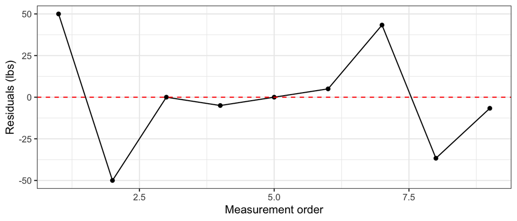

**Long Description**

The horizontal axis is labelled “Measurement order” and goes from 0 to 10 with labels of 2.5, 5, and 7.5.

The vertical axis is labelled “Residuals (lbs)” and goes from about –50 to +50 with labels of –50, -25, 0, +25, and +50.

The plot contains two sets of elements.

- A dashed horizontal red line at a residual value of 0.
- A set of 9 points where each point represents a case in the data set. The points positions are determined by the case’s order of measurement and the case’s residual value.
- The points are roughly centered around the dashed red line with three points above the line, 4 points below the line and two points on the line.
- Half of the points are with -25 and +25 for the resdiual values.
- The points are connected by line segments along the path (1, 50), (2, -50), (3, 0), (4, -5), (5, 0), (6, 5), (7, 43.33), (8, -36.67) and (9, -6.67).

What we’re looking for is a pattern. A “cloud” of points or the lack of any pattern is what we’re hoping for. If instead we see something that reminds us of things we saw in college algebra, pre-calculus, trig, calculus, or another math classes, then we have a problem. For the Honey data (Figure 6), I do not see any indication of a pattern.

#### 5.3.2.2 Durbin-Watson Statistic

In addition to the index plots, we can also use the Durbin-Watson statistic to measure the level of autocorrelation (or serial correlation) in our data. Again, we must know the measurement order of our data.

If there is no autocorrelation (i.e., independent observations), then the DW statistic should be around 2. A *rough* rule of thumb is that DW values that are less than 1.5 or greater than 2.5 are causes for concern. However, the DW statistic is sensitive to things such as long runs of the same treatment/group in the data. This means that there is a lot of wiggle room in this rule of thumb. Only use the DW statistic in conjunction with the index plot AND your knowledge of the study. Use `car::durbinWatsonTest(honeyModel)$dw` to get the value of the Durbin-Watson statistic.

### 5.3.3 Putting Things Together

You’ve now seen how to assess the Independent Observations assumption by referencing the study design as well as by using an Index plot and the Durbin-Watson statistic. Use the information in Oehlert about the Resin Lifetime example (Example 3.2 in the textbook) as well as fact that the data appear in measurement order in the DAT file to assess the assumption of Independent Observations. How do you feel about whether the Independent Observations assumption is satisfied?

# 6 Conducting the Parametric Shortcut

Technically speaking, we’ve already taken the parametric shortcut when we ran the `aov` (or `lm`) command. However, there are a couple of things that we will want to double check before we actually look at the results of the shortcut. First, we need to state our final assessment of assumptions. Second, we need to remind ourselves of our decision rule.

## 6.1 Assessment of Assumptions

When you go to make your final determination about whether the data meet the assumptions for the parametric shortcut, keep in mind whether we have a balanced design. Balanced designs give us a bit more flexibility to accommodate minor to moderate violations to the Gaussian and Homoscedasticity. While both the Song Knowledge study and the Honey study are balanced designs, I’m going to propose two different decisions. I’m going to state that the violations are too numerous for the Honey study to proceed. However, I’ll cautiously proceed with the Song Knowledge study.

If you have been following along with the Resin data, I feel that we can proceed (cautiously) with the Resin Lifetimes data.

## 6.2 Decision Rule

Ideally, you’ll have decided on your decision rule before you collect and analyze your data. The most common decision rule used in ANOVA contexts is the *p*-value method.

Remember, that you chose an overall Type I risk level, $\mathcal{E}_{I}$ during your study design process. You need to use that value to guide our selection of an *Unusualness Threshold*, *UT*. Keep in mind that the *UT* is going to serve as the way to decide whether we reject or fail to reject the null hypothesis. The Unusualness Threshold (also called “Level of Significance”) is the maximum percentage of the time we anticipate seeing “unusual events” given the null hypothesis. This is a probability value and we’re free to choose the value provided that $UT \leq \mathcal{E}_{I}$. (There are some subtle distinctions between the ideas of Unusualness Threshold/Level of Significance and Type I risk that we won’t get into.)

For this guide, I’m going to use $\mathcal{E}_{I}=0.05$ and $UT=0.03$.

## 6.3 Quick Look of Results

Once we’re ready to look at the results, we can quickly view them by using either the `summary` or `anova` functions in R with an input of our model object.

```r
# Code for Quickly Looking at Results ----
## Summary example with the Song Knowledge study
summary(songModel)
```

```
            Df Sum Sq Mean Sq F value Pr(>F)
Year         2  40.67   20.33   1.906  0.204
Residuals    9  96.00   10.67
```

```r
## Anova example with Resin Lifetimes study
anova(resinModel)
```

```
Analysis of Variance Table

Response: log10Lifetime
          Df Sum Sq Mean Sq F value    Pr(>F)
temp       4 3.5376 0.88441  96.363 < 2.2e-16 ***
Residuals 32 0.2937 0.00918
---
Signif. codes:  0 '***' 0.001 '**' 0.01 '*' 0.05 '.' 0.1 ' ' 1
```

The `anova` function adds a bit more context to the output that is absent when using the `summary` function. However, it is good to keep in mind that both of these approaches are really only meant to be viewed by you, the analyst. If we want to build a professional-looking ANOVA table that is useful to others, we can do much better.

## 6.4 Professional ANOVA Tables

We could take the data from the `summary`/`anova` call and make them look professional. However, neither of these calls incorporate measures of practical significance that would be found in a *modern professional ANOVA table*. To make such tables we’ll draw upon the `{parameters}`, `{knitr}`, and `{kableExtra}` packages.

### 6.4.1 Example Table

```r
# Code for Professional, Modern ANOVA Tables ----
## Song Knowledge study
parameters::model_parameters(
  model = songModel,
  es_type = c("eta", "omega", "epsilon")
) |>
  knitr::kable(
  digits = 4,
  col.names = c(
    "Source", "SS", "df", "MS", "F", "p-value",
    "Eta Sq.", "Omega Sq.", "Epsilon Sq."),
  # caption = "Modern ANOVA Table for Song Knowledge Study",
  booktabs = TRUE,
  align = c("l", rep("c", 8)),
  # format = "latex"
  ) |>
  kableExtra::kable_classic(
    html_font = "arial",
    font_size = 14,
    latex_options = c("HOLD_position")
  )
```

**1**

The `model_parameters` function will exact the all necessary information for building the ANOVA table out of our model AND will calculate the effect sizes we list in the `es_type` argument.

**2**

The `digits` argument of `kable` will apply automatic rounding for us. There is not need to report more than 4 digits; you can go fewer.

**3**

The `col.names` argument allows us to put in more human-friend column headers. Names should appear in order, with no skips.

**4**

If you are using R Markdown or going to copy/paste the table to another system, be sure to use the `caption` argument (uncommented) to get a table title.

**5**

The `align` argument allows you to specify the column alignment (left, center, right) for each column.

**6**

If you are knitting/render to PDF and keep running into a table that spills over the left/right edges of the page, add the `format` argument with the value `"latex"`.

**7**

You can ignore the `html_font` argument in your own code.

**8**

The `latex_options` listed here are useful if you are using R Markdown/Quarto to create a PDF.

Table 1: Modern ANOVA Table for Song Knowledge Study

| Source | SS | df | MS | F | p-value | Eta Sq. | Omega Sq. | Epsilon Sq. |
| --- | --- | --- | --- | --- | --- | --- | --- | --- |
| Year | 40.6667 | 2 | 20.3333 | 1.9063 | 0.2041 | 0.2976 | 0.1312 | 0.1415 |
| Residuals | 96.0000 | 9 | 10.6667 |  |  |  |  |  |

The above table code is meant to be re-useable with the appropriate updates to match your current context. You’ll need to change the value of the `model` and `caption` arguments at minimum. You can customize the appear of the table further with the `kable_classic` is a pre-set styles from the `{kableExtra}` package. There are additional pre-set table styles you can check out or you can use the `kable_styling` function to customize your table’s appearance. Check out this useful page for additional examples: [kableExtra](https://haozhu233.github.io/kableExtra/).

**WarningQuarto and `{kableExtra}`**

If you are using a Quarto Document, you’ll want to make sure that you do each of the following:

1. Use the `label` code chunk option with the form `tbl-name`,
2. Use`tbl-cap` code chunk option to set the table title instead of the `caption` argument of `kable`.
3. Use `html-table-processing: none` code chunk option to ensure that the your table gets processed correctly.

#### 6.4.1.1 Interpreting Table 1

We can see that a STAT461 undergraduate’s year in school accounts for about 1.9 times as much variation as the residuals in Table 1. Drawing upon the balanced design to grant some robustness to the heteroscedasticity, we would anticipate seeing an *F* ratio at least as large as this ~20% of the time we would repeat the experiment if there truly was no impact of year in school on quiz score. Since our *p*-value is greater than our Unusualness Threshold (*UT*), we have an event that is “usual” (or typical) under the null hypothesis model and we would fail to reject the null hypothesis. Further, we can note that the *s*-value for this study is 2.29 bits of information against the null hypothesis; that is to say, getting this result is only a little bit more surprising then getting two heads in a row when flipping a fair coin but less surprising than getting three heads in a row. We will decide to act as if a student’s year in school does not impact how well they do on a song knowledge quiz.

**Tip*S*-Values**

The *s*-value (a.k.a. Shannon information measure, binary surprise index, and surprisal) is transformation of *p*-values to assist with interpretations. Here, we imaging flipping (or tossing) a fair coin *s* times and getting the same result for every flip (i.e., all heads or all tails). The larger the value of *s*, the more surprising the result is and the more evidence we have against the idea that the coin is fair (i.e., our null hypothesis).

To convert a *p*-value into an *s*-value, we use the following formula
$$s = -\log_2(p)$$
We can implement this formula in R with the command `sValue <- -1*log(pValue, base = 2)` where `pValue` is our *p*-value obtained from our test (you’ll need to either provide this value or extract it from your model/summary object). We can then call `sValue` for use in our document.

Whole number values of *s* (e.g., 1, 2, 3, etc.) are interpreted as the number of successive coin flips all resulting in the same outcome. Non-whole number values of *s* aren’t directly interpretable in this fashion, but you can use the whole numbers of either side as part of your interpretation, as was shown in the example.

### 6.4.2 Your Turn

Create and interpret a professional, modern ANOVA table for the Resin Lifetimes study. When you’re ready, check your answer below.

**NoteResin Lifetimes Example**

```r
# Code for Professional, Modern ANOVA Tables ----
## Resin Lifetime study
parameters::model_parameters(
  model = resinModel,
  es_type = c("eta", "omega", "epsilon")
) |>
  knitr::kable(
  digits = 4,
  col.names = c(
    "Source", "SS", "df", "MS", "F", "p-value",
    "Eta Sq.", "Omega Sq.", "Epsilon Sq."),
  # caption = "Modern ANOVA Table for Resin Lifetimes Study",
  booktabs = TRUE,
  align = c("l", rep("c", 8))
  ) |>
  kableExtra::kable_classic(
    html_font = "arial",
    font_size = 14,
    latex_options = c("HOLD_position")
  ) |>
  kableExtra::footnote(
    general = "Computer rounding has made the p-value look like zero.",
    general_title = "Note. ",
    footnote_as_chunk = TRUE
  )
```

Table 2: Modern ANOVA Table for Resin Lifetimes Study

| Source | SS | df | MS | F | p-value | Eta Sq. | Omega Sq. | Epsilon Sq. |
| --- | --- | --- | --- | --- | --- | --- | --- | --- |
| temp | 3.5376 | 4 | 0.8844 | 96.363 | 0 | 0.9233 | 0.9116 | 0.9138 |
| Residuals | 0.2937 | 32 | 0.0092 |  |  |  |  |  |

Note. Computer rounding has made the p-value look like zero.

### 6.4.3 Rounding *p*-values

Notice that both Table 1 and Table 2 look much more professional than the raw output we got from using `summary` and `anova`. Further, by using this approach with the `model_parameters` function, we’ve gotten our three estimates of effect sizes for the model (i.e., practical significance). There is a downside in this approach: the *p*-value in Table 2 has been made to look equal to zero. We know that while *p*-values may be essentially equal to zero, they are never actually zero. Hence, why I added a footnote to Table 2.

Alternatively, we could adopt the convention of reporting that the *p*-value is less than a given threshold. Part of my suite of ANOVA tools is the `pvalRound` function. This function takes an input *p* and the argument `digits` to determine whether the input is less than $10^{-\text{digits}}$. If so, the function returns a character string such as “< 0.0001” for `digits = 4` (the default). If the input *p* is larger than $10^{-\text{digits}}$, then the function returns the input unchanged.

```r
# Code for Professional, Modern ANOVA Tables ----
## Resin Lifetime study
model_parameters(
  model = resinModel,
  es_type = c("eta", "omega", "epsilon")
) |>
  dplyr::mutate(
    p = case_when(
      is.na(p) ~ NA_character_,
      .default = pvalRound(p, digits = 3)
    )
  ) |>
  kable(
    digits = 3,
    col.names = c(
      "Source", "SS", "df", "MS", "F", "p-value",
      "Eta Sq.", "Omega Sq.", "Epsilon Sq."),
    # caption = "Modern ANOVA Table for Resin Lifetimes Study",
    booktabs = TRUE,
    align = c("l", rep("c", 8))
  ) |>
  kable_classic(
    html_font = "arial",
    font_size = 14,
    latex_options = c("HOLD_position")
  )
```

Table 3: Modern ANOVA Table for Resin Lifetimes Study with Rounded P-Values

| Source | SS | df | MS | F | p-value | Eta Sq. | Omega Sq. | Epsilon Sq. |
| --- | --- | --- | --- | --- | --- | --- | --- | --- |
| temp | 3.538 | 4 | 0.884 | 96.363 | < 0.001 | 0.923 | 0.912 | 0.914 |
| Residuals | 0.294 | 32 | 0.009 |  |  |  |  |  |

Either approach is sufficient. You only need to worry about fixing a *p*-value looking like 0 IF you have a *p*-value that is sufficiently close to zero (i.e., less than 0.0001). While 0.0001 is a fairly common threshold, you could update the `pvalRounding` function to use another threshold such as 0.001. I do not recommend going smaller than 0.0001 (`digits = 4`).

# 7 Reporting Estimates of Factor Effects

One the last things we can do related to the ANOVA omnibus analysis is to estimate the various parameters in our models. We can do this in two ways: point and interval estimation. Thinking back to HW #1.2, both of these approaches have their strengths and their weaknesses.

## 7.1 Point Estimation

Here’s how we can get the point estimates for our Grand Mean and factor effects.

**Make sure that you’ve told R to use the Sum to Zero constraint before proceeding.**

To get these point estimates, we will use the `dummy.coef` function. To make the results look professional, we’ll again make use the `knitr` and `kableExtra` packages.

```r
# Making a Profession Table of Coefficients/Point Estimates ----
## If you want to quickly look, just enter dummy.coef(songModel) into the console

## Song Knowledge study
pointEst <- dummy.coef(songModel)
# pointEst
pointEst <- unlist(pointEst)
names(pointEst) <- c("Grand Mean", "Junior", "Senior",
                     "Other")

data.frame("Estimate" = pointEst) |>
  kable(
    digits = 2,
    # caption = "Point Estimates from the Song Knowledge Study",
    booktabs = TRUE,
    align = "c"
  ) |>
  kable_classic(
    html_font = "arial",
    font_size = 14,
    latex_options = c("HOLD_position"),
    full_width = FALSE
  )
```

**1**

Look at the output of `pointEst` before continuing so you know in what order the estimates appear so that you can apply more meaningful names.

**2**

You MUST look at the output of `pointEst` before you assign new names to the elements inside `pointEst`. If you don’t, you’ll risk misnaming elements.

**3**

From here down is just making a professional looking table of the point estimates.

**4**

The `full_width` argument is only needed in HTML outputs. When rendering to PDF, the LaTeX engine will automatically ensure the table doesn’t use up the entire width of the page.

Table 4: Point Estimates for the Song Knowledge Study

|  | Estimate |
| --- | --- |
| Grand Mean | 4.67 |
| Junior | 2.33 |
| Senior | -2.17 |
| Other | -0.17 |

If you just call `dummy.coef(songModel)` in the console, you’ll see a value labelled `(Intercept)`; this is the value of the *Grand Sample Arithmetic Mean*. The other values should be labelled by factor name and level name. These point estimates are what will fill our various screens (plus the residuals).

Keep in mind that the estimates in Table 4 are *rates*. Thus, for the Song Knowledge study, we would interpret this value as 4.67 points per student; our entire sample accumulated 4.67 times as many points as sampled students.

### 7.1.1 Your Turn

Attempt to come up with the code that makes table of point estimates for the Resin Lifetime study. Additionally, practice interpreting these point estimates. When you’re ready, check your answer below.

**NoteResin Lifetimes Example**

```r
# Making a Profession Table of Coefficients/Point Estimates ----

## Resin Lifetimes study
pointEst <- dummy.coef(resinModel)
pointEst <- unlist(pointEst)
names(pointEst) <- c("Grand Mean", "175ºC", "194ºC",
                 "213ºC", "231ºC", "250ºC")

data.frame("Estimate" = pointEst) |>
  kable(
    digits = 2,
    # caption = "Point Estimates for the Resin Lifetimes Study",
    booktabs = TRUE,
    align = "c"
  ) |>
  kable_classic(
    html_font = "arial",
    font_size = 14,
    latex_options = c("HOLD_position"),
    full_width = FALSE
  )
```

Table 5: Point Estimates for the Resin Lifetimes Study

|  | Estimate |
| --- | --- |
| Grand Mean | 1.44 |
| 175ºC | 0.49 |
| 194ºC | 0.19 |
| 213ºC | -0.06 |
| 231ºC | -0.24 |
| 250ºC | -0.38 |

## 7.2 Interval Estimation

Thinking back the activities we did in Unit 1 (i.e., HW #1.2–Estimation Exploration), we know that while point estimates are much more interpretable, they have extremely low success rates. On the flip side, interval estimation (i.e., confidence intervals) have better success rates but are harder to interpret.

In ANOVA contexts, there are two places where we often use interval estimation. The most common area is in a phase called *Post Hoc Analysis* which will be covered in the next guide. The other place is for estimating the factor effects.

One of the easiest approaches is to use the `{emmeans}` package to build confidence intervals for us. The catch is that the `{emmeans}` back focuses on marginal (cell) means rather than factor effects. That is, this package returns point and interval estimates based on $\mu_{i\bullet}$ rather than $\alpha_i$. This is not necessarily a problem, as long as you are aware of the change.

```r
# Producing Point and Interval Estimates for Marginal Means ----
resinMeans <- emmeans(
  object = resinModel,
  specs = ~ temp,
  level = 0.9,
  adjust = "bonferroni"
)

resinMeans <- as.data.frame(resinMeans)
resinMeans |>
  kable(
    digits = 2,
    # caption = "Marginal Mean Estimates from the Resin Lifetime Study",
    col.names = c("Stress Temp. (ºC)", "Marginal Mean", "SE", "df",
                  "Lower Bound", "Upper Bound"),
    booktabs = TRUE,
    align = "c"
  ) |>
  kable_classic(
    html_font = "arial",
    font_size = 14,
    latex_options = c("HOLD_position"),
    full_width = FALSE
  ) |>
  footnote(
    general = "Bonferroni Adjustment for an overall 10% Type I Error Rate.",
    footnote_as_chunk = TRUE
  )
```

**1**

Pass your ANOVA object.

**2**

Specify what element you want (i.e, your factor).

**3**

This should be the result of 1 - Type I Error.

**4**

List which adjustment method you want used; more on this choice in the next guide.

**5**

From here down is to make a professional looking table of the interval estimates.

Table 6: Marginal Mean Estimates from the Resin Lifetime Study

| Stress Temp. (ºC) | Marginal Mean | SE | df | Lower Bound | Upper Bound |
| --- | --- | --- | --- | --- | --- |
| 175 | 1.93 | 0.03 | 32 | 1.85 | 2.02 |
| 194 | 1.63 | 0.03 | 32 | 1.55 | 1.71 |
| 213 | 1.38 | 0.03 | 32 | 1.29 | 1.46 |
| 231 | 1.19 | 0.04 | 32 | 1.11 | 1.28 |
| 250 | 1.06 | 0.04 | 32 | 0.96 | 1.15 |

Note: Bonferroni Adjustment for an overall 10% Type I Error Rate.

Table 6 shows the results of using the `{emmeans}` package. By saving the output of `emmeans` function to the object `resinMeans`, I can then access these values whenever I want. This makes writing out an interpretation sentence a bit easier (especially for updating). For example, I might want to say the following: Using our particular sample and 90% Bonferroni adjusted method, the lifetime performance of the resin (in log10 hours) when heated to 175ºC might be between 1.85 and 2.02 log10 hours per circuit.

If you want, you can convert the estimates in Table 6 by subtracting the value of the *GSAM* from the Marginal Means, Lower Bound, and Upper Bound columns. This will move you back to the factor effects model that our ANOVA table and point estimates (Table 5) are centered around.

# 8 Practice

The key to building your fluency with any statistical software as well as new ideas is to practice. Practice writing and running the commands. Practice writing out descriptions of plots and tables along with providing interpretations. You have all of examples in this document as well as the Fall 2024 Paper Plane study data. If you want some additional practice, you can check out the data frame `InsectSprays` that is part of R. Use `data("InsectSprays")` to load the data and `help("InsectSprays")` to bring up some documentation about the data.

# 9 Code Appendix

```r
# Load useful packages ----
packages <- c("tidyverse", "hasseDiagram", "knitr", "kableExtra",
              "car", "psych", "parameters", "emmeans")
lapply(
  X = packages,
  FUN = library,
  character.only = TRUE,
  quietly = TRUE
)

# Code for setting the constraint ----
options(contrasts = c("contr.sum", "contr.poly"))

# Code for controlling table options ----
# Tell Knitr to use empty space instead of NA in printed tables
options(knitr.kable.NA = "")

# Code for Loading Data ----
## Song Data
songData <- read.table(
  file = "https://raw.githubusercontent.com/neilhatfield/STAT461/main/dataFiles/songKnowledge_Fa23.csv",
  header = TRUE,
  sep = ","
)
### Set year to an ordered factor
songData$Year <- factor(
  x = songData$Year,
  levels = c("Junior", "Senior", "Other")
)

## Honey Data--Manual Entry
honey <- data.frame(
  Amount = c(150, 50, 100, 85, 90, 95, 130, 50, 80),
  Varietal = rep(c("Clover", "Orange Blossom", "Alfalfa"), each = 3)
)
### Set Varietal to factor (no particular order)
honey$Varietal <- as.factor(honey$Varietal)

## Resin Lifetimes Data
resin <- read.table(
  file = "https://raw.github.com/neilhatfield/STAT461/main/dataFiles/resinLifetimes.dat",
  header = TRUE,
  sep = "" # Notice the change in separator
)
#### Set temp to factor
resin$temp <- as.factor(resin$temp)

### Change the name of the y column to something more meaningful
names(resin)[which(names(resin) == "y")] <- "log10Lifetime"

# Code for loading Neil's extra tools ----
source("https://raw.github.com/neilhatfield/STAT461/main/rScripts/ANOVATools.R")

# Checking the first two base requirements
str(songData)
str(honey)
str(resin)

# Code for a Hasse Diagram ----
## The Honey Study
modelLabels <- c("1 Make Honey 1", "3 Varietal 2", "9 (Hives) 6")
modelMatrix <- matrix(
  data = c(FALSE, FALSE, FALSE, TRUE, FALSE, FALSE, TRUE, TRUE, FALSE),
  nrow = 3,
  ncol = 3,
  byrow = FALSE
)
hasseDiagram::hasse(
 data = modelMatrix,
 labels = modelLabels
)

# Code for Building ANOVA Models ----
## Song Knowledge study
songModel <- aov(
  formula = Score ~ Year,
  data = songData,
  na.action = "na.omit"
)
# Code for Building ANOVA Models ----
## Honey study
honeyModel <- aov(
  formula = Amount ~ Varietal,
  data = honey,
  na.action = "na.omit"
)
# Code for Building ANOVA Models ----
## Resin Lifetime study
resinModel <- aov(
  formula = log10Lifetime ~ temp,
  data = resin,
  na.action = "na.omit"
)
# Code for Making a QQ Plot of Residuals ----
## Song Knowledge Study
car::qqPlot(
  x = songModel$residuals,
  distribution = "norm",
  envelope = 0.9,
  id = FALSE,
  pch = 20,
  ylab = "Residuals (points)"
)

# Code for making QQ Plot of Residuals ----
## Honey Study
car::qqPlot(
  x = honeyModel$residuals,
  distribution = "norm",
  envelope = 0.9,
  id = FALSE,
  pch = 20,
  ylab = "Residuals (lbs)"
)

# Code for Getting Sample Skewness and Sample Excess Kurtosis ----
## Honey Study
psych::skew(honeyModel$residuals)
psych::kurtosi(honeyModel$residuals)
# Code for Making Strip Charts ----
## Song Knowledge study
ggplot(
  data = data.frame(
    residuals = songModel$residuals,
    fitted = songModel$fitted.values
  ),
  mapping = aes(x = fitted, y = residuals)
) +
  geom_point(size = 2) +
  theme_bw() +
  labs(
    x = "Fitted values (points)",
    y = "Residuals (points)"
  )
# Code for Making Strip Charts ----
## Honey study
ggplot(
  data = data.frame(
    residuals = honeyModel$residuals,
    fitted = honeyModel$fitted.values
  ),
  mapping = aes(x = fitted, y = residuals)
) +
  geom_point(size = 2) +
  theme_bw() +
  labs(
    x = "Fitted values (lbs)",
    y = "Residuals (lbs)"
  )
# Code for Index Plots ----
## Honey Study
ggplot(
  data = data.frame(
    residuals = honeyModel$residuals,
    index = 1:length(honeyModel$residuals)
  ),
  mapping = aes(x = index, y = residuals)
) +
  geom_point(size = 1.5) +
  geom_line() +
  theme_bw() +
  geom_hline(
    yintercept = 0,
    linetype = "dashed",
    color = "red"
  ) +
  labs(
    x = "Measurement order",
    y = "Residuals (lbs)"
  )

# Code for Quickly Looking at Results ----
## Summary example with the Song Knowledge study
summary(songModel)

## Anova example with Resin Lifetimes study
anova(resinModel)

# Code for Professional, Modern ANOVA Tables ----
## Song Knowledge study
parameters::model_parameters(
  model = songModel,
  es_type = c("eta", "omega", "epsilon")
) |>
  knitr::kable(
  digits = 4,
  col.names = c(
    "Source", "SS", "df", "MS", "F", "p-value",
    "Eta Sq.", "Omega Sq.", "Epsilon Sq."),
  # caption = "Modern ANOVA Table for Song Knowledge Study",
  booktabs = TRUE,
  align = c("l", rep("c", 8)),
  # format = "latex"
  ) |>
  kableExtra::kable_classic(
    html_font = "arial",
    font_size = 14,
    latex_options = c("HOLD_position")
  )

# Code to convert p-value to s-value ----
sVal <- -1*log(anova(songModel)$`Pr(>F)`[[1]], base = 2)
# Code for Professional, Modern ANOVA Tables ----
## Resin Lifetime study
parameters::model_parameters(
  model = resinModel,
  es_type = c("eta", "omega", "epsilon")
) |>
  knitr::kable(
  digits = 4,
  col.names = c(
    "Source", "SS", "df", "MS", "F", "p-value",
    "Eta Sq.", "Omega Sq.", "Epsilon Sq."),
  # caption = "Modern ANOVA Table for Resin Lifetimes Study",
  booktabs = TRUE,
  align = c("l", rep("c", 8))
  ) |>
  kableExtra::kable_classic(
    html_font = "arial",
    font_size = 14,
    latex_options = c("HOLD_position")
  ) |>
  kableExtra::footnote(
    general = "Computer rounding has made the p-value look like zero.",
    general_title = "Note. ",
    footnote_as_chunk = TRUE
  )

# Code for Professional, Modern ANOVA Tables ----
## Resin Lifetime study
model_parameters(
  model = resinModel,
  es_type = c("eta", "omega", "epsilon")
) |>
  dplyr::mutate(
    p = case_when(
      is.na(p) ~ NA_character_,
      .default = pvalRound(p, digits = 3)
    )
  ) |>
  kable(
    digits = 3,
    col.names = c(
      "Source", "SS", "df", "MS", "F", "p-value",
      "Eta Sq.", "Omega Sq.", "Epsilon Sq."),
    # caption = "Modern ANOVA Table for Resin Lifetimes Study",
    booktabs = TRUE,
    align = c("l", rep("c", 8))
  ) |>
  kable_classic(
    html_font = "arial",
    font_size = 14,
    latex_options = c("HOLD_position")
  )

# Making a Profession Table of Coefficients/Point Estimates ----
## If you want to quickly look, just enter dummy.coef(songModel) into the console

## Song Knowledge study
pointEst <- dummy.coef(songModel)
# pointEst
pointEst <- unlist(pointEst)
names(pointEst) <- c("Grand Mean", "Junior", "Senior",
                     "Other")

data.frame("Estimate" = pointEst) |>
  kable(
    digits = 2,
    # caption = "Point Estimates from the Song Knowledge Study",
    booktabs = TRUE,
    align = "c"
  ) |>
  kable_classic(
    html_font = "arial",
    font_size = 14,
    latex_options = c("HOLD_position"),
    full_width = FALSE
  )

# Making a Profession Table of Coefficients/Point Estimates ----

## Resin Lifetimes study
pointEst <- dummy.coef(resinModel)
pointEst <- unlist(pointEst)
names(pointEst) <- c("Grand Mean", "175ºC", "194ºC",
                 "213ºC", "231ºC", "250ºC")

data.frame("Estimate" = pointEst) |>
  kable(
    digits = 2,
    # caption = "Point Estimates for the Resin Lifetimes Study",
    booktabs = TRUE,
    align = "c"
  ) |>
  kable_classic(
    html_font = "arial",
    font_size = 14,
    latex_options = c("HOLD_position"),
    full_width = FALSE
  )

# Producing Point and Interval Estimates for Marginal Means ----
resinMeans <- emmeans(
  object = resinModel,
  specs = ~ temp,
  level = 0.9,
  adjust = "bonferroni"
)

resinMeans <- as.data.frame(resinMeans)
resinMeans |>
  kable(
    digits = 2,
    # caption = "Marginal Mean Estimates from the Resin Lifetime Study",
    col.names = c("Stress Temp. (ºC)", "Marginal Mean", "SE", "df",
                  "Lower Bound", "Upper Bound"),
    booktabs = TRUE,
    align = "c"
  ) |>
  kable_classic(
    html_font = "arial",
    font_size = 14,
    latex_options = c("HOLD_position"),
    full_width = FALSE
  ) |>
  footnote(
    general = "Bonferroni Adjustment for an overall 10% Type I Error Rate.",
    footnote_as_chunk = TRUE
  )
```

[One-Way ANOVA: Parametric Shortcut Guide](https://neilhatfield.github.io/STAT461/codingRGuides/Unit%203%20Guides/Stat461.OnewayANOVA_Shortcut.html) © 2026 by [Neil J. Hatfield](https://neilhatfield.github.io/) is licensed under [CC BY-NC-SA 4.0](https://creativecommons.org/licenses/by-nc-sa/4.0/)

[figure not shown]